# scATAC-seq analysis of adult mouse brain

Manisha Barse

```r
library(Signac)
library(Seurat)
library(EnsDb.Mmusculus.v79)
library(ggplot2)
library(patchwork)
set.seed(1234)
```

## Pre-processing workflow

```r
counts <- Read10X_h5("atac_v1_adult_brain_fresh_5k_filtered_peak_bc_matrix.h5")
```

```r
#counts
#157797 x 5337 sparse Matrix of class "dgCMatrix"
```

```r
metadata <- read.csv(
  file = "atac_v1_adult_brain_fresh_5k_singlecell.csv",
  header = TRUE,
  row.names = 1
)
```

```r
brain_assay <- CreateChromatinAssay(
  counts = counts,
  sep = c(":", "-"),
  genome = "mm10",
  fragments = 'atac_v1_adult_brain_fresh_5k_fragments.tsv.gz',
  min.cells = 1
)
```

```
## Computing hash
```

```r
brain <- CreateSeuratObject(
  counts = brain_assay,
  assay = 'peaks',
  project = 'ATAC',
  meta.data = metadata
)
```

```r
brain
```

```
## An object of class Seurat
## 157203 features across 5337 samples within 1 assay
## Active assay: peaks (157203 features, 0 variable features)
##  2 layers present: counts, data
```

By printing the assay we can see some of the additional information that can be contained in the ChromatinAssay, including motif information, gene annotations, and genome information.

```r
brain[['peaks']]
```

```
## ChromatinAssay data with 157203 features for 5337 cells
## Variable features: 0
## Genome: mm10
## Annotation present: FALSE
## Motifs present: FALSE
## Fragment files: 1
```

Applying granges() to SeuratObject, to see the genomic ranges associated with each feature in the object.

```r
granges(brain)
```

```
## GRanges object with 157203 ranges and 0 metadata columns:
##            seqnames            ranges strand
##               <Rle>         <IRanges>  <Rle>
##        [1]     chr1   3094708-3095552      *
##        [2]     chr1   3119414-3121782      *
##        [3]     chr1   3204809-3205178      *
##        [4]     chr1   3217330-3217359      *
##        [5]     chr1   3228123-3228463      *
##        ...      ...               ...    ...
##   [157199]     chrY 90761049-90762169      *
##   [157200]     chrY 90800417-90800831      *
##   [157201]     chrY 90804515-90805440      *
##   [157202]     chrY 90808545-90809111      *
##   [157203]     chrY 90810741-90810960      *
##   -------
##   seqinfo: 21 sequences from an unspecified genome; no seqlengths
```

Next, adding gene annotations to the brain object for the mouse genome. This will allow downstream functions to pull the gene annotation information directly from the object.

```r
# extract gene annotations from EnsDb
annotations <- GetGRangesFromEnsDb(ensdb = EnsDb.Mmusculus.v79)
```

```r
# change to UCSC style since the data was mapped to hg19
seqlevels(annotations) <- paste0('chr', seqlevels(annotations))
genome(annotations) <- "mm10"
```

```r
# add the gene information to the object
Annotation(brain) <- annotations
```

## Computing QC Metrics

```r
brain <- NucleosomeSignal(object = brain)
```

We can look at the fragment length periodicity for all the cells, and group by cells with high or low nucleosomal signal strength. You can see that cells which are outliers for the mononucleosomal or nucleosome-free ratio have different banding patterns. The remaining cells exhibit a pattern that is typical for a successful ATAC-seq experiment.

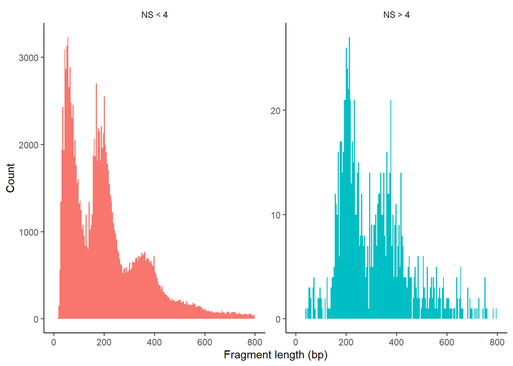

```r
brain$nucleosome_group <- ifelse(brain$nucleosome_signal > 4, 'NS > 4', 'NS < 4')
FragmentHistogram(object = brain, group.by = 'nucleosome_group', region = 'chr1-1-10000000')
```

The enrichment of Tn5 integration events at transcriptional start sites (TSSs) can also be an important quality control metric to assess the targeting of Tn5 in ATAC-seq experiments. As per the ENCODE consortium, a TSS enrichment score is defined as the number of Tn5 integration site around the TSS normalized to the number of Tn5 integration sites in flanking regions.

```r
brain <- TSSEnrichment(brain, fast = FALSE)
```

```
## Extracting TSS positions
```

```
## Finding + strand cut sites
```

```
## Finding - strand cut sites
```

```
## Computing mean insertion frequency in flanking regions
```

```
## Normalizing TSS score
```

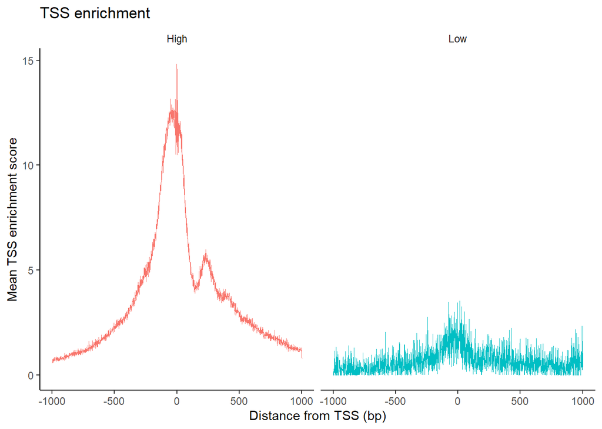

```r
brain$high.tss <- ifelse(brain$TSS.enrichment > 2, 'High', 'Low')
TSSPlot(brain, group.by = 'high.tss') + NoLegend()
```

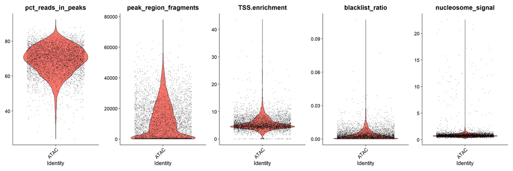

```r
brain$pct_reads_in_peaks <- brain$peak_region_fragments / brain$passed_filters * 100
brain$blacklist_ratio <- brain$blacklist_region_fragments / brain$peak_region_fragments

VlnPlot(
  object = brain,
  features = c('pct_reads_in_peaks', 'peak_region_fragments',
               'TSS.enrichment', 'blacklist_ratio', 'nucleosome_signal'),
  pt.size = 0.1,
  ncol = 5
)
```

Let us remove cells that are outliers for these QC metrics.

```r
brain <- subset(
  x = brain,
  subset = peak_region_fragments > 3000 &
    peak_region_fragments < 100000 &
    pct_reads_in_peaks > 40 &
    blacklist_ratio < 0.025 &
    nucleosome_signal < 4 &
    TSS.enrichment > 2
)
```

```r
brain
```

```
## An object of class Seurat
## 157203 features across 3512 samples within 1 assay
## Active assay: peaks (157203 features, 0 variable features)
##  2 layers present: counts, data
```

## Normalization and linear dimensional reduction

```r
# Running TF-IDF normalization on the brain dataset to transform the count matrix into a term frequency-inverse document frequency (TF-IDF) matrix, which weights the features by their importance.
brain <- RunTFIDF(brain)
```

```
## Performing TF-IDF normalization
```

```r
# Finding top features based on TF-IDF scores above the minimum cutoff 'q0', ensuring that only informative features are retained for downstream analysis.
brain <- FindTopFeatures(brain, min.cutoff = 'q0')

# Running singular value decomposition (SVD) on the TF-IDF normalized data to perform linear dimensional reduction, capturing the main patterns of variation in the dataset.
brain <- RunSVD(object = brain)
```

```
## Running SVD
```

```
## Scaling cell embeddings
```

To assess if the first LSI component captures sequencing depth (technical variation) instead of biological variation, we can utilize the DepthCor() function to evaluate the correlation between each LSI component and sequencing depth. If a strong correlation is observed with sequencing depth, it suggests that the component should be removed from downstream analysis.

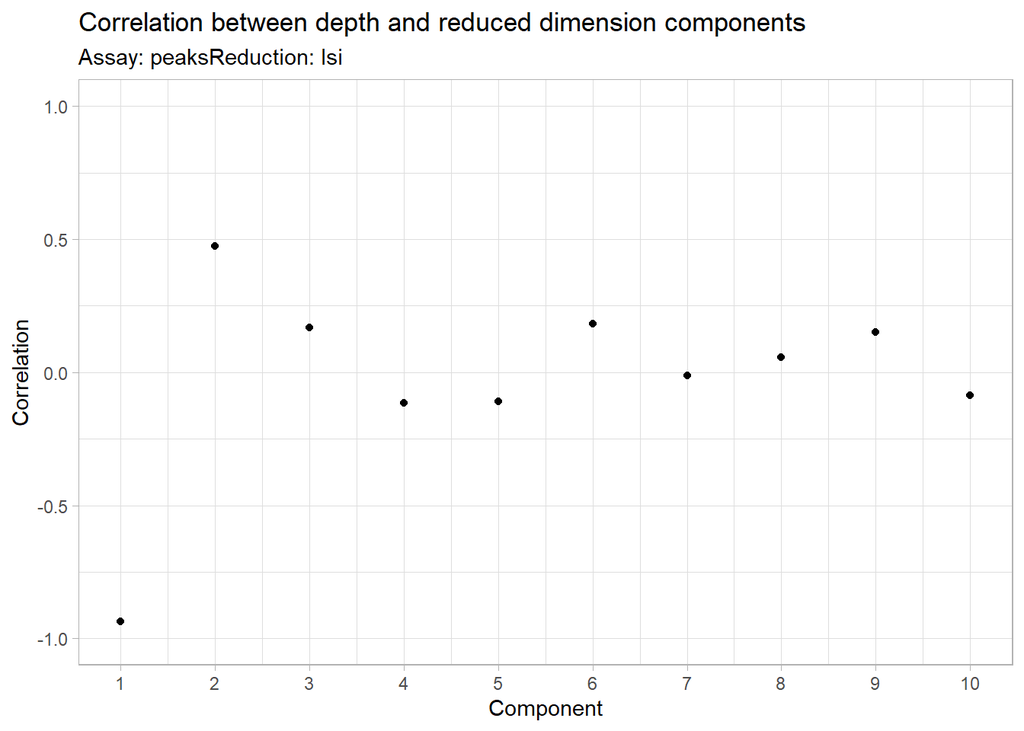

```r
DepthCor(brain)
```

Here we observe a strong correlation between the first Latent Semantic Indexing (LSI) component and the total number of counts for the cell. Hence, we will proceed with downstream analysis excluding this component.

## Non-linear dimension reduction and clustering

Now that the cells are embedded in a low-dimensional space, we can use methods commonly applied for the analysis of scRNA-seq data to perform graph-based clustering and non-linear dimension reduction for visualization. These functions, `RunUMAP()`, `FindNeighbors()`, and `FindClusters()`, are all provided by the Seurat package.

```r
# Perform dimensionality reduction using UMAP on the 'lsi' space with dimensions 2 to 30.
brain <- RunUMAP(
  object = brain,
  reduction = 'lsi',
  dims = 2:30
)
```

```
## Found more than one class "dist" in cache; using the first, from namespace 'BiocGenerics'
```

```
## Also defined by 'spam'
```

```
## Found more than one class "dist" in cache; using the first, from namespace 'BiocGenerics'
```

```
## Also defined by 'spam'
```

```r
# Find nearest neighbors in the 'lsi' space with dimensions 2 to 30.
brain <- FindNeighbors(
  object = brain,
  reduction = 'lsi',
  dims = 2:30
)
```

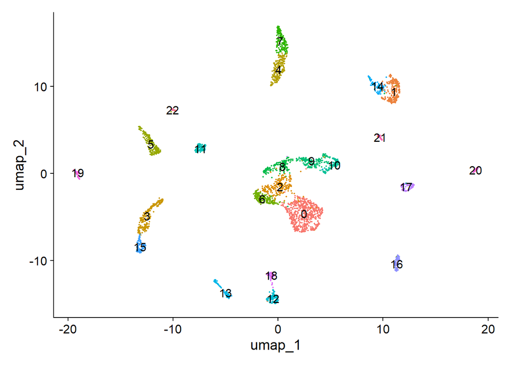

```r
# Find clusters in the UMAP space. Adjusting the resolution parameter to control the granularity of the identified cell clusters.
brain <- FindClusters(
  object = brain,
  algorithm = 3,
  resolution = 1.2,
  verbose = FALSE
)

# Generate a UMAP-based visualization of the data with cluster labels.
DimPlot(object = brain, label = TRUE) + NoLegend()
```

## Create a gene activity matrix

Gene activity refers to the level of expression or activity of genes across different cells in the dataset.

```r
# Compute gene activities from the Seurat object 'brain'
gene.activities <- GeneActivity(brain)
```

Add the gene activity matrix to the Seurat object as a new assay named ‘RNA’. This allows for easy access and manipulation of the gene activity data within the Seurat framework.

```r
brain[['RNA']] <- CreateAssayObject(counts = gene.activities)
```

```r
# Normalize the gene activity data using the 'LogNormalize' method
brain <- NormalizeData(
  object = brain,
  assay = 'RNA',
  normalization.method = 'LogNormalize',
  scale.factor = median(brain$nCount_RNA)
)
```

Normalization is performed to remove technical variations and ensure that the gene activity values are comparable across cells. The scale factor used for normalization is set to the median of the total counts of RNA in the dataset.

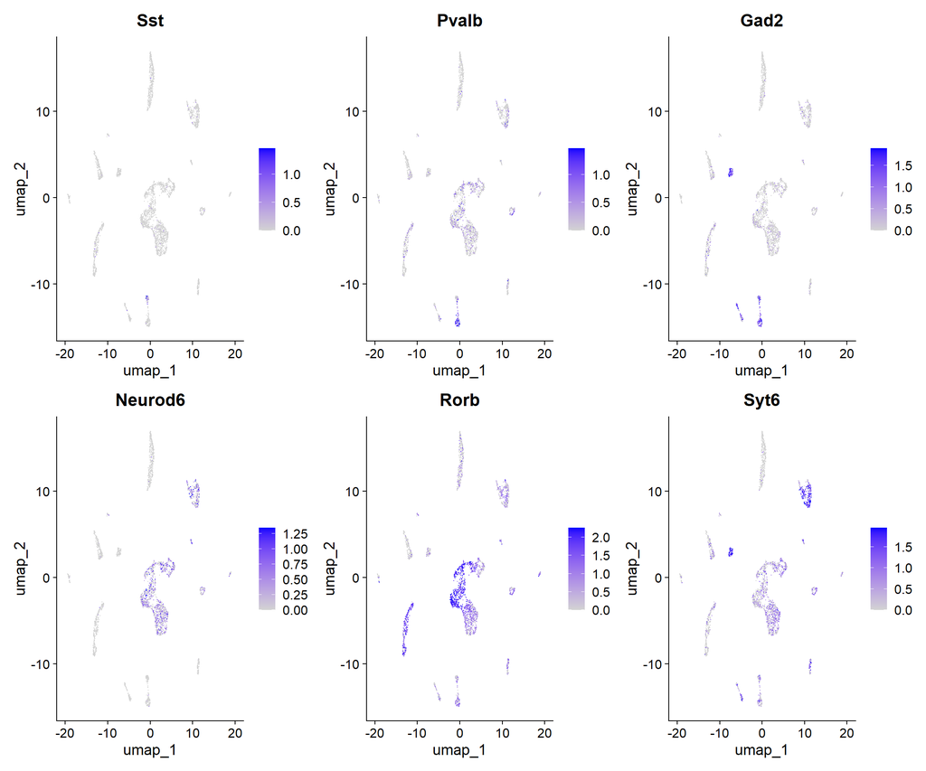

```r
# Set the default assay of the Seurat object 'brain' to 'RNA'
DefaultAssay(brain) <- 'RNA'

# Generate a feature plot to visualize gene expression of specific genes
FeaturePlot(
  object = brain,
  features = c('Sst','Pvalb',"Gad2","Neurod6","Rorb","Syt6"),
  pt.size = 0.1,
  max.cutoff = 'q95',
  ncol = 3
)
```

## Integrating scRNA-seq data with scATAC-seq data

We can classify cells based on an scRNA-seq experiment from the adult mouse brain, to help interpret the scATAC-seq data. We utilize methods for cross-modality integration and label transfer, as described in the Seurat vignette. * Original methods described in the publication: [DOI: 10.1016/j.cell.2019.05.031](https://doi.org/10.1016/j.cell.2019.05.031) * More in-depth tutorial available [here](https://satijalab.org/seurat/v3.0/atacseq_integration_vignette.html)

- Raw data for the scRNA-seq experiment can be downloaded from the [Allen Institute website](http://celltypes.brain-map.org/api/v2/well_known_file_download/694413985)
- Code used to construct the Seurat object can be found on [GitHub](https://github.com/satijalab/Integration2019/blob/master/preprocessing_scripts/allen_brain.R)
- Alternatively, you can download the pre-processed Seurat object from [here](https://signac-objects.s3.amazonaws.com/allen_brain.rds)

```r
# Load the pre-processed scRNA-seq data from the file 'allen_brain.rds' and update the Seurat object.
allen_rna <- readRDS("allen_brain.rds")
allen_rna <- UpdateSeuratObject(allen_rna)
```

[output not shown]

[output not shown]

[output not shown]

[output not shown]

[output not shown]

[output not shown]

[output not shown]

[output not shown]

[output not shown]

[output not shown]

[output not shown]

[output not shown]

[output not shown]

[output not shown]

[output not shown]

[output not shown]

[output not shown]

[output not shown]

[output not shown]

[output not shown]

```r
allen_rna <- FindVariableFeatures(
  object = allen_rna,
  nfeatures = 5000
)
```

Identify the top 5000 variable features in the scRNA-seq data.

```r
# Find anchors between the scRNA-seq and scATAC-seq datasets using canonical correlation analysis (CCA) on dimensions 1 to 30.
transfer.anchors <- FindTransferAnchors(
  reference = allen_rna,
  query = brain,
  reduction = 'cca',
  dims = 1:30
)
```

```
## Running CCA
```

```
## Merging objects
```

```
## Finding neighborhoods
```

```
## Finding anchors
```

```
##  Found 6862 anchors
```

```r
# Transfer labels from the scRNA-seq data to the scATAC-seq data using the identified anchors and dimensionality reduction results from the scATAC-seq data.
predicted.labels <- TransferData(
  anchorset = transfer.anchors,
  refdata = allen_rna$subclass,
  weight.reduction = brain[['lsi']],
  dims = 2:30
)
```

```
## Finding integration vectors
```

```
## Finding integration vector weights
```

```
## Predicting cell labels
```

```r
# Add the predicted cell labels from the scRNA-seq data as metadata to the scATAC-seq object.
brain <- AddMetaData(object = brain, metadata = predicted.labels)
```

Create UMAP visualizations for both scRNA-seq and scATAC-seq data, with cells colored by subclass (scRNA-seq) and predicted cell labels (scATAC-seq).

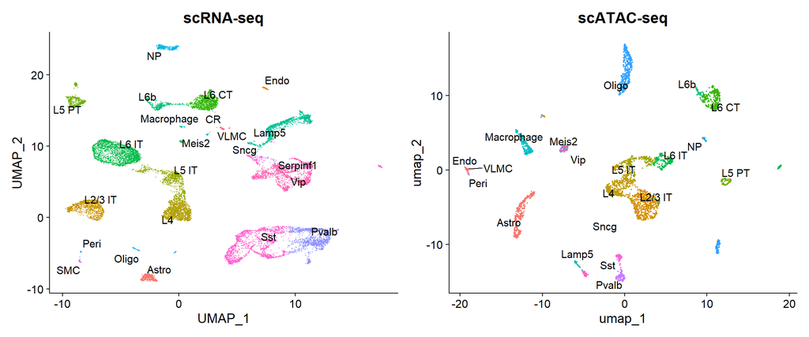

```r
plot1 <- DimPlot(allen_rna, group.by = 'subclass', label = TRUE, repel = TRUE) + NoLegend() + ggtitle('scRNA-seq')
plot2 <- DimPlot(brain, group.by = 'predicted.id', label = TRUE, repel = TRUE) + NoLegend() + ggtitle('scATAC-seq')
plot1 + plot2
```

Integrating scRNA-seq with scATAC-seq, we validate scATAC-seq clustering using scRNA-seq cell type labels. Anchors are identified between datasets, transferring scRNA-seq labels to scATAC-seq cells. Using canonical correlation analysis (CCA), we establish cross-modality correspondences. Cell type labels from scRNA-seq are transferred to scATAC-seq. Comparing RNA-based classifications to scATAC-seq UMAP clusters ensures consistency. This validation boosts confidence in scATAC-seq cluster annotations and facilitates comprehensive biological interpretation of single-cell chromatin accessibility data.

We see consistent alignment between RNA-based classifications and the UMAP visualization, derived solely from ATAC-seq data